# 데이터 시각화란?

위키백과에선 데이터 시각화를 아래와 같이 정의하고 있다.

> **데이터 시각화(data visualization)**는 데이터 분석 결과를 쉽게 이해할 수 있도록 시각적으로 표현하고 전달되는 과정을 말한다. 데이터 시각화의 목적은 도표(graph)라는 수단을 통해 정보를 명확하고 효과적으로 전달하는 것이다.

맞다. 나도 단순히 데이터를 그래프화하는 것이 아니라, 자신의 메세지를 명확하게 전달하는 것이 중요하다고 생각한다.

데이터스토리를 작성할 때, 제일 시간을 많이 소비하는 것이 바로 '시각화'이다.  
어떻게 시각화해야 내가 중요하게 생각하는 부분을 잘 나타낼 수 있을지, 독자들이 그래프를 잘 이해할 수 있을지 고민하기 때문이다.

'그래프에 메세지 담기' 시리즈에서는 데이터스토리 작성 중 고민하던 내용과 해결방안을 공유하려고 한다.

# 그래프에 의도 담기 1

일정기간 나라별로 사망자 수가 얼마나 늘어났는지, 얼마나 빠른 속도로 늘어났는지 확인하던 중 시각화에서 문제가 발생하였다.

| date | Belgium | China | France | Germany | Iran | Italy | Netherlands | Spain | USA | United Kingdom |
| --- | --- | --- | --- | --- | --- | --- | --- | --- | --- | --- |
| 2020-04-03 | 1143 | 3326 | 6520 | 1275 | 3294 | 14681 | 1490 | 11198 | 7418 | 3611 |
| 2020-04-04 | 1283 | 3330 | 7574 | 1444 | 3452 | 15362 | 1656 | 11947 | 8387 | 4320 |
| 2020-04-05 | 1447 | 3333 | 8093 | 1584 | 3603 | 15887 | 1771 | 12641 | 9489 | 4943 |
| 2020-04-06 | 1632 | 3335 | 8926 | 1810 | 3739 | 16523 | 1874 | 13341 | 10783 | 5385 |
| 2020-04-07 | 2035 | 3335 | 10343 | 2016 | 3872 | 17127 | 2108 | 14045 | 12798 | 6171 |

- 일정기간(2020-04-03 ~ 2020-04-12), 나라별 코로나 사망자 수 데이터.

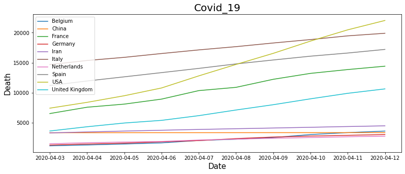

임팩트가 부족하다는 것을 조금 더 구체적으로 설명하면,

- POINT 1. **USA_코로나 사망자 수의 폭발적 증가를 표현하고 싶다.** 3위에서 1위로 변화하는 과정을 조금 더 눈에 띄게 표현하고 싶다.
- POINT 2. **하위 그룹에 속한 나라의 사망자 수의 변화를 파악하기 힘들다.** 하위 그룹의 사망자 수의 변화도 한눈에 파악할 수 있었으면 좋겠다.

## 두가지 포인트를 해결하고, 데이터의 변화를 조금 더 역동적으로 표현하는 방법은 없을까?

방법이 있었다. 영상으로 표현하는 것이다!! 유튜브 채널 ['데이터 다람쥐'](https://www.youtube.com/watch?v=RyU53Hr5yXI)처럼 말이다. 이제 문제는 파이썬에서 가능한가? 이다. 물론 가능하다!!

### 그 해결방법 중 하나인 **Bar Chart Race**를 소개하려고 한다.

- keyword는 Bar Chart Race, 구글에 치면 여러가지 방법이 나온다.

```
bcr.bar_chart_race(
    df = df, # 사용할 데이터
    orientation = 'h', # 'h' or 'v' 막대의 방향을 결정한다.
    sort = 'desc', # 'asc' or 'desc' 오름차순, 내림차순
    title = 'Covid_19' # title 입력
)
```

코드도 간단하다. 위에서 사용한 파라미터 값 이외에 다양한 파라미터들이 존재한다. 파라미터값을 지정하여 그래프를 다양하게 표현할 수 있다.  
더 많은 파라미터를 사용하고 싶다면 https://github.com/dexplo/bar_chart_race 를 참고하면 좋을 거 같다.

(matplotlib을 이용한 다른 방법도 있다. 참고 > https://pratapvardhan.com/blog/bar-chart-race-python-matplotlib/)

[video not shown]

- Bar Chart Race 이용하여 데이터를 영상으로 표현하니 POINT 1, POINT 2가 해결되었다.
- USA의 폭발적 증가가 눈에 잘 보인다. 3위에서 1위로 변화하는 과정을 잘 파악할 수 있다.
- 하위 그룹인 China, Netherlands, Belgium, Germany의 수치도 한눈에 파악가능하며 하위그룹 간의 치열한 순위 경쟁도 볼 수 있다.

## 의도가 담겨 있느냐?

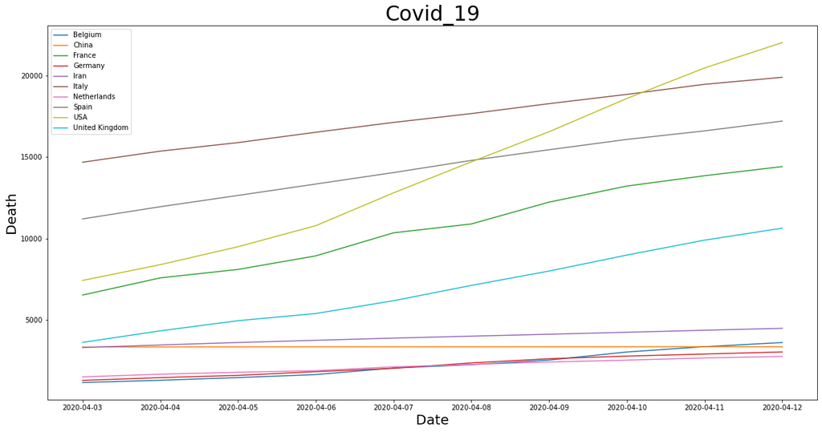

[video not shown]

똑같은 데이터를 이용하여 두가지 형태로 시각화해보았다. 두 그래프를 비교하였을 때, 차이가 단지 '움직임'뿐이라 생각할 수 있다.

더욱 중요하게 보아야 할 것은 **'그래프에 메시지를 담았냐'** 다. 위의 그래프는 데이트를 단순히 시각화시킨 것이고,  
**아래의 그래프는 USA의 코로나 사망자 수의 폭발적 증가와 하위그룹에서의 변화를 더 잘 표현하고자 하는 의도가 담겨있다.**  
그 결과 위의 그래프보다 아래의 그래프를 봤을 때 데이터를 더욱 더 빠르고 직관적으로 이해할 수 있었다.(나만 그런가? 댓글 남겨줘요.)

시각화는 단순히 데이터를 그래프로 표현하는 것이 아닌 거 같다. "시각화는 의도에 맞게 데이터를 표현하는 것" 이렇게 봐야 조금 더 정확하다.  
그렇기에 데이터에 따라 시각화 방법이 달라져야 하는 것은 물론이고 **전달하고자 하는 메시지에 따라서도 시각화 방법이 달라져야 한다.**(인정?)